# ggplot2

github.com/nacmarino/introducaoR

## ggplot2

- Escrito por Hadley Wickham, quando ainda era um estudante de pós graduação;
- É um dos pacotes gráficos mais utilizados na linguagem R, junto do pacote `base` e `lattice`;
- É a implementação do *The Grammar of Graphics*, idéia desenvolvida por Leland Wilkinson.

[figure not shown]

## ggplot2

### “Resumidamente, a gramática nos diz que um gráfico deve ser mapeado (**mapping**) a partir dos dados (**data**), de acordo com a aparência (**aesthetic**) (color, formato, tamanho) de objetos geométricos (**geometric**) (pontos, linhas, barras). A figura também pode conter transformações estatísticas dos dados, sendo desenhada a partir de um sistema específico de coordenadas.”

Do livro "*ggplot2*"

## ggplot2

- Faça um paralelo com a nossa gramática:
  - sujeito (*data*, *aesthetics*)
  - verbo (*geometries*, *facets*)
  - adjetivo (*color*, *fill*, *shape*, *alpha*)
- Diminui a distância da mente para a página.

## Filosofia do ggplot2

- Você desenha, adicionando e modificando as camadas durante o processo.
  - Não é preciso realizar todo o desenho em um único objeto (ao contrário do `lattice`);
  - Uma vez que você tenha adicionado uma entidade ao gráfico, você pode alterar ela posteriormente (ao contrário do `base`);
  - Gráficos complexos, com comandos simples (ao contrário do `lattice` e `base`).

## ggplot2

```r
# para instalação do pacote
install.packages("ggplot2")
```

```r
# para carregar o pacote
library(ggplot2)
```

## ggplot2

Exemplo: os conjunto de dados `CO2` do pacote `datasets` (`?CO2`).

```r
library(datasets);data("CO2")
```

```r
str(CO2)
```

```
## Classes 'nfnGroupedData', 'nfGroupedData', 'groupedData' and 'data.frame':   84 obs. of  5 variables:
##  $ Plant    : Ord.factor w/ 12 levels "Qn1"<"Qn2"<"Qn3"<..: 1 1 1 1 1 1 1 2 2 2 ...
##  $ Type     : Factor w/ 2 levels "Quebec","Mississippi": 1 1 1 1 1 1 1 1 1 1 ...
##  $ Treatment: Factor w/ 2 levels "nonchilled","chilled": 1 1 1 1 1 1 1 1 1 1 ...
##  $ conc     : num  95 175 250 350 500 675 1000 95 175 250 ...
##  $ uptake   : num  16 30.4 34.8 37.2 35.3 39.2 39.7 13.6 27.3 37.1 ...
##  - attr(*, "formula")=Class 'formula' length 3 uptake ~ conc | Plant
##   .. ..- attr(*, ".Environment")=<environment: R_EmptyEnv>
##  - attr(*, "outer")=Class 'formula' length 2 ~Treatment * Type
##   .. ..- attr(*, ".Environment")=<environment: R_EmptyEnv>
##  - attr(*, "labels")=List of 2
##   ..$ x: chr "Ambient carbon dioxide concentration"
##   ..$ y: chr "CO2 uptake rate"
##  - attr(*, "units")=List of 2
##   ..$ x: chr "(uL/L)"
##   ..$ y: chr "(umol/m^2 s)"
```

## *qplot*

- É similar à função `plot` do pacote `base`, mas possui os elementos do *The Grammar of Graphics*.

```r
# "..." são os aesthetics (size, shape, color, fill)
args(qplot)
```

```
## function (x, y = NULL, ..., data, facets = NULL, margins = FALSE,
##     geom = "auto", xlim = c(NA, NA), ylim = c(NA, NA), log = "",
##     main = NULL, xlab = deparse(substitute(x)), ylab = deparse(substitute(y)),
##     asp = NA, stat = NULL, position = NULL)
## NULL
```

## *qplot*

- Exercício 1: por que não precisamos especificar o **geom**?

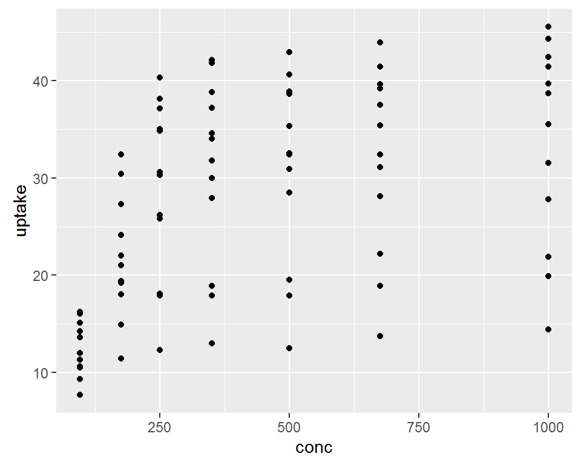

```r
qplot(x = conc, y = uptake, data = CO2)
```

## *qplot*

- Podemos adicionar elementos gráficos, baseado em alguma informação sobre os dados.

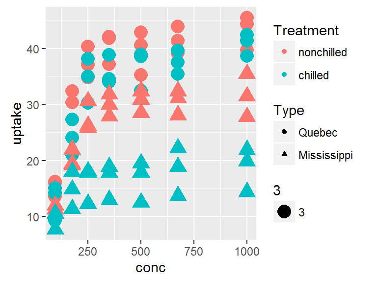

```r
qplot(x = conc, y = uptake, data = CO2, shape = Type,
      size = 3, colour = Treatment)
```

## *qplot*

- Podemos criar painéis diferentes com o argumento `facets`.

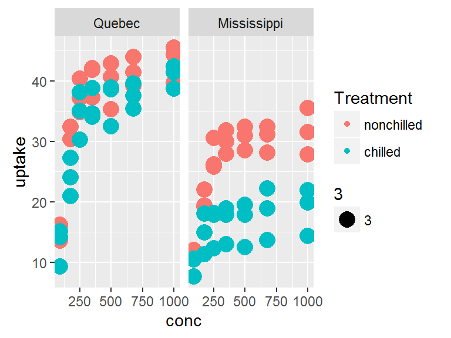

```r
qplot(x = conc, y = uptake, data = CO2, facets = ~Type,
      size = 3, colour = Treatment)
```

## *qplot*

- Também podemos alterar o título dos eixos.

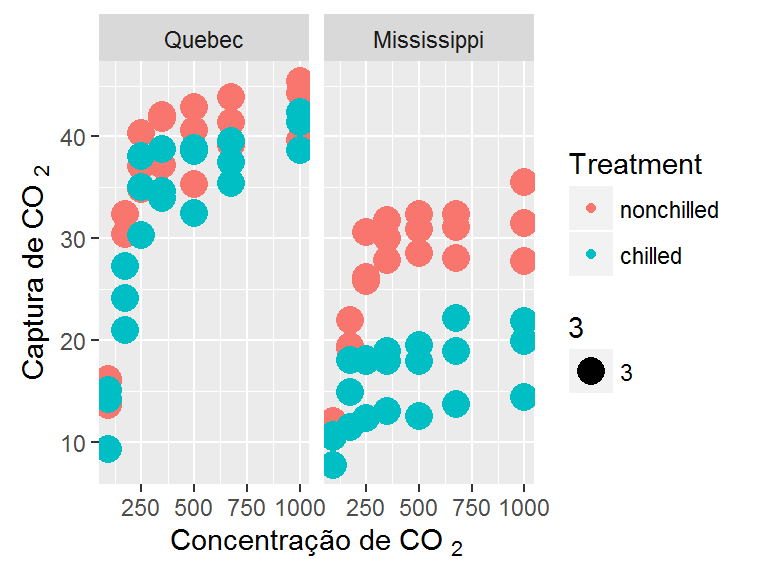

```r
qplot(x = conc, y = uptake, data = CO2, facets = ~Type,
      size = 3, colour = Treatment,
      xlab = expression(paste("Concentração de CO "[2])),
      ylab = expression(paste("Captura de CO "[2])))
```

## *qplot*

- Especificando outros tipos de `geom`, gráficos diferentes podem ser feitos.

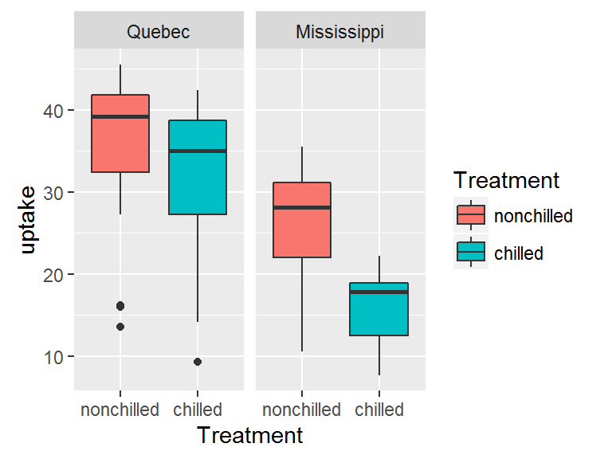

```r
qplot(x = Treatment, y = uptake, data = CO2, facets = ~Type,
      geom = "boxplot", fill = Treatment)
```

## *qplot*

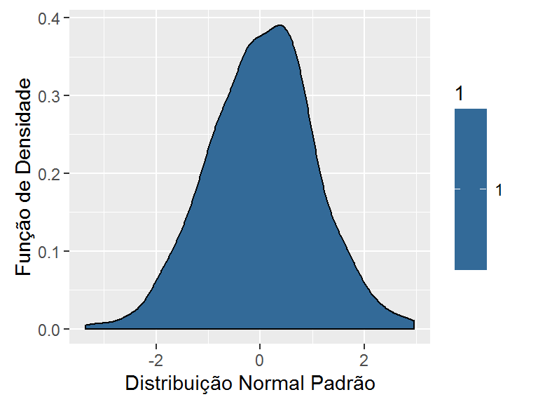

```r
set.seed(59)
normal <- rnorm(n = 1000, mean = 0, sd = 1)
qplot(x = normal, geom = "density", fill = 1,
      xlab = "Distribuição Normal Padrão",
      ylab = "Função de Densidade")
```

## Um resumo sobre *qplot*

- Funciona de forma similar à função `plot`;
- Customização do gráfico é limitada;
- Intenção é produzir gráficos rápidos, para exploração dos dados.

## *ggplot*

- É a função chave do `ggplot2`;
- Permite customização total do gráfico.

## ggplot

- Aqui, a filosofia do *The Grammar of Graphics* é explicitamente colocada em prática.
- Vamos começar desenhando a base do gráfico: `data` e `aesthetics`.

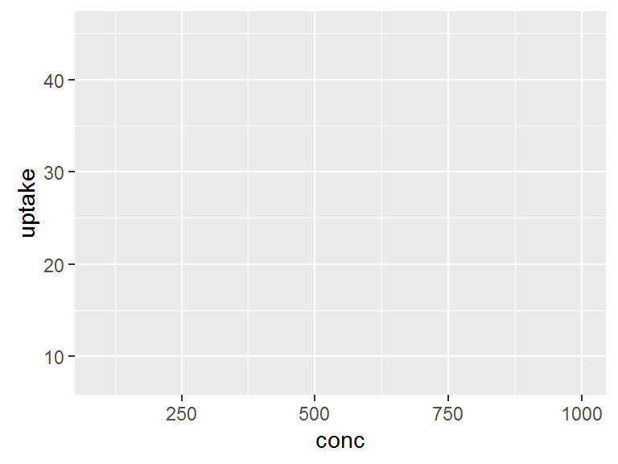

```r
g <- ggplot(data = CO2, mapping = aes(x = conc, y = uptake))
g
```

## ggplot

- Vamos separar os gráficos de acordo com algumas categorias: `facets`.

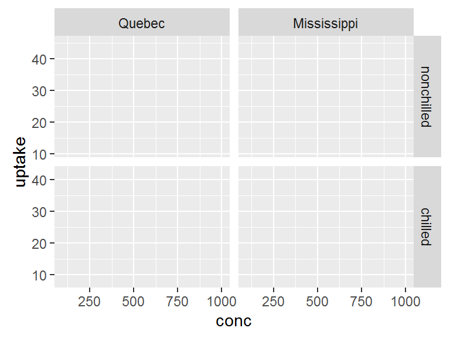

```r
g <- g + facet_grid(Treatment ~ Type, scales = "free_y")
g
```

## ggplot

- Vamos desenhar o que queremos no gráfico: `geom`.
- Vamos adicionar também como queremos o `geom`: `colour`, `shape`, `alpha`…

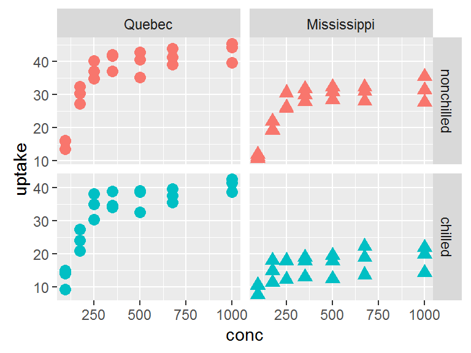

```r
g <- g + geom_point(aes(colour = Treatment, shape = Type), size = 3, show.legend = FALSE)
g
```

## ggplot

- Podemos editar as cores dos pontos manualmente.

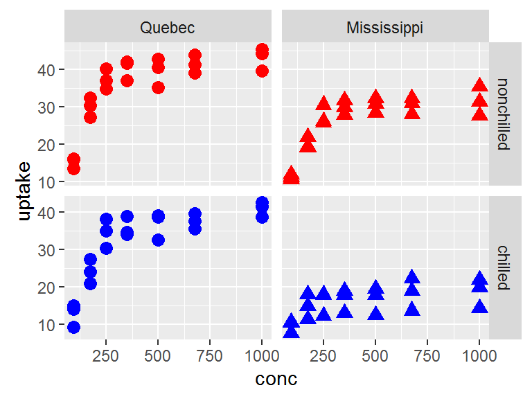

```r
g <- g + scale_colour_manual(values = c("red", "blue"))
g
```

## ggplot

- Editar o título dos eixos.

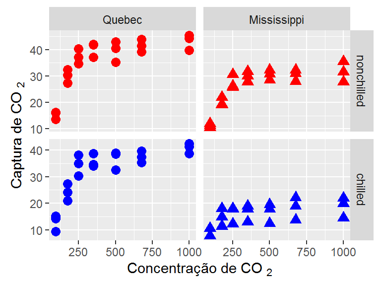

```r
g <- g + xlab(expression(paste("Concentração de CO "[2]))) +
  ylab(expression(paste("Captura de CO "[2])))
g
```

## ggplot

- E adicionar uma linha de tendência.

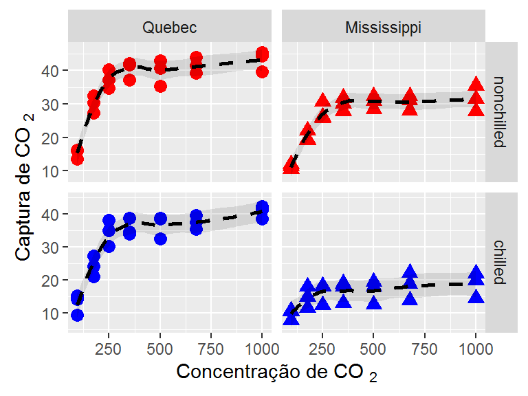

```r
g <- g + geom_smooth(linetype = 2, fill = "black", alpha = 0.1, colour = "black")
g
```

## ggplot

Você possui duas formas de customizar a aparência do gráfico:  
+ Temas pré-determinados: `theme_bw`, `theme_classic`, `theme_dark`, `theme_light`

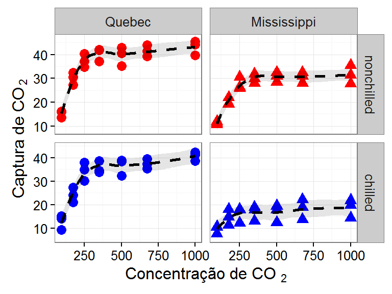

```r
g + theme_bw()
```

## ggplot

Você possui duas formas de customizar a aparência do gráfico:  
+ Temas pré-determinados: `theme_bw`, `theme_classic`, `theme_dark`, `theme_light`  
+ Temas pessoal: `theme`

```r
?theme
```

## ggplot

- Você pode adicionar o tema criado diretamente ao gráfico.

```r
g + theme(panel.grid = element_blank(),
        panel.background = element_rect(fill = NA, colour = "black"),
        strip.background = element_rect(fill = NA, colour = "black"),
        axis.text = element_text(colour = "black", size = 10),
        axis.title = element_text(colour = "black", size = 12, face = "bold"),
        strip.text = element_text(colour = "black", size = 10, face = "bold"),
        axis.text.x = element_text(margin = margin(1,1,5,1)),
        axis.text.y = element_text(margin = margin(1,1,1,5)))
```

[output not shown]

## ggplot

- Você pode adicionar o tema criado diretamente ao gráfico.

## ggplot

- Ou, você pode criar um objeto com o tema…

```r
tema <- theme(panel.grid = element_blank(),
        panel.background = element_rect(fill = NA, colour = "black"),
        strip.background = element_rect(fill = NA, colour = "black"),
        axis.text = element_text(colour = "black", size = 10),
        axis.title = element_text(colour = "black", size = 12, face = "bold"),
        strip.text = element_text(colour = "black", size = 10, face = "bold"),
        axis.text.x = element_text(margin = margin(1,1,5,1)),
        axis.text.y = element_text(margin = margin(1,1,1,5)))
```

## ggplot

- …e adicionar ele ao gráfico (especialmente útil quando você quer criar vários gráficos com a mesma cara).

```r
g + tema
```

[output not shown]

## Exercício 2: sua vez!

- Com os dados do `gapminder`:
1. Construa um gráfico da relação entre o ano e o GDP para cada continente;
2. Construa um gráfico com a distribuição de expectativa de vida para cada continente;
3. Construa um gráfico com a distribuição de expectativa de vida.

## Interação com o dplyr

- O ggplot2 pode interagir com as funcionalidade do pacote `dplyr`:
  - `select`, `filter`, `mutate`, `summarize`
  - Pipping: `%>%`

```r
library(dplyr)
library(gapminder)
```

## Interação com o dplyr

- Você pode realizar uma manipulação com um conjunto de dados, e encaminhar o último formato da planilha de dados diretamente para o `ggplot`.

[figure not shown]

```r
gapminder %>%
  filter(country == "Brazil") %>%
  ggplot(mapping = aes(x = year, y = gdpPercap)) +
  geom_point(aes(size = pop, colour = lifeExp), show.legend = FALSE) +
  geom_smooth() +
  theme_bw()
```

## Interação com o dplyr

- Isto pode ser importante em alguns casos como, por exemplo, um gráfico de barras.

```r
CO2 %>%
  group_by(Type, Treatment) %>%
  summarise(media_uptake = mean(uptake),
            desvio_uptake = sd(uptake),
            observacoes = n(),
            erro_uptake = desvio_uptake/sqrt(observacoes))
```

```
## Source: local data frame [4 x 6]
## Groups: Type [?]
##
##          Type  Treatment media_uptake desvio_uptake observacoes
##        (fctr)     (fctr)        (dbl)         (dbl)       (int)
## 1      Quebec nonchilled     35.33333      9.596371          21
## 2      Quebec    chilled     31.75238      9.644823          21
## 3 Mississippi nonchilled     25.95238      7.402136          21
## 4 Mississippi    chilled     15.81429      4.058976          21
## Variables not shown: erro_uptake (dbl)
```

## Interação com o dplyr

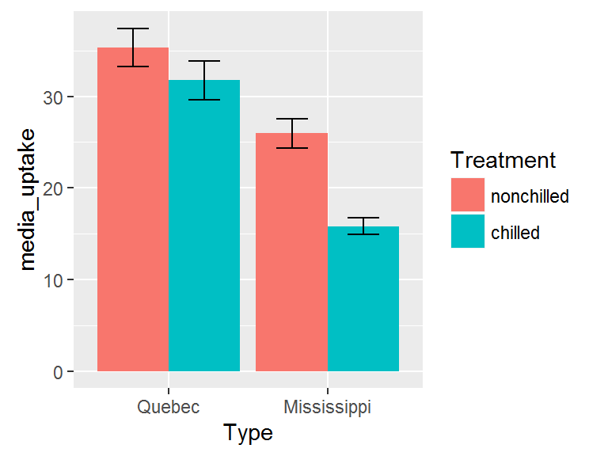

```r
CO2 %>%
  group_by(Type, Treatment) %>%
  summarise(media_uptake = mean(uptake), desvio_uptake = sd(uptake),
            observacoes = n(), erro_uptake = desvio_uptake/sqrt(observacoes)) %>%
  ggplot(aes(x = Type, y = media_uptake, fill = Treatment)) +
  geom_bar(stat = "identity", position = "dodge") +
  geom_errorbar(aes(ymin = media_uptake - erro_uptake,
                    ymax = media_uptake + erro_uptake),
                position = position_dodge(width = 0.9), width = 0.4)
```

## Outras funcionalidades disponíveis no ggplot2

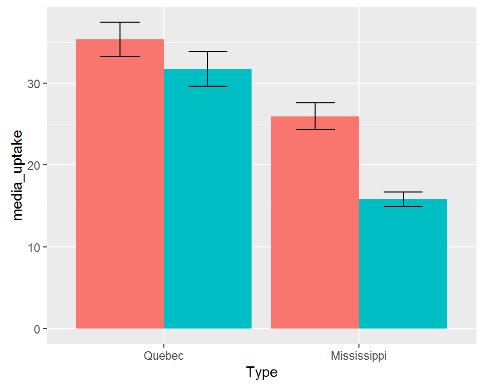

```r
figura
```

## Outras funcionalidades disponíveis no ggplot2

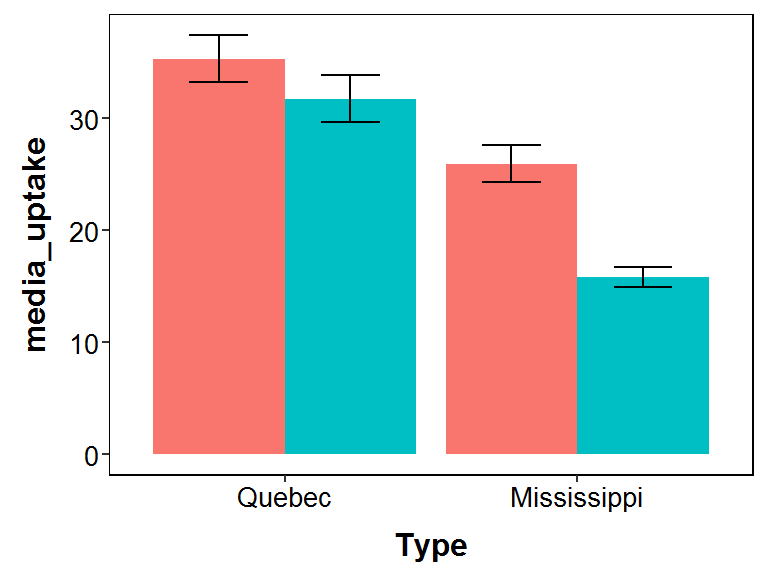

```r
figura <- figura + tema
figura
```

## Mudar o conteúdo do eixo x

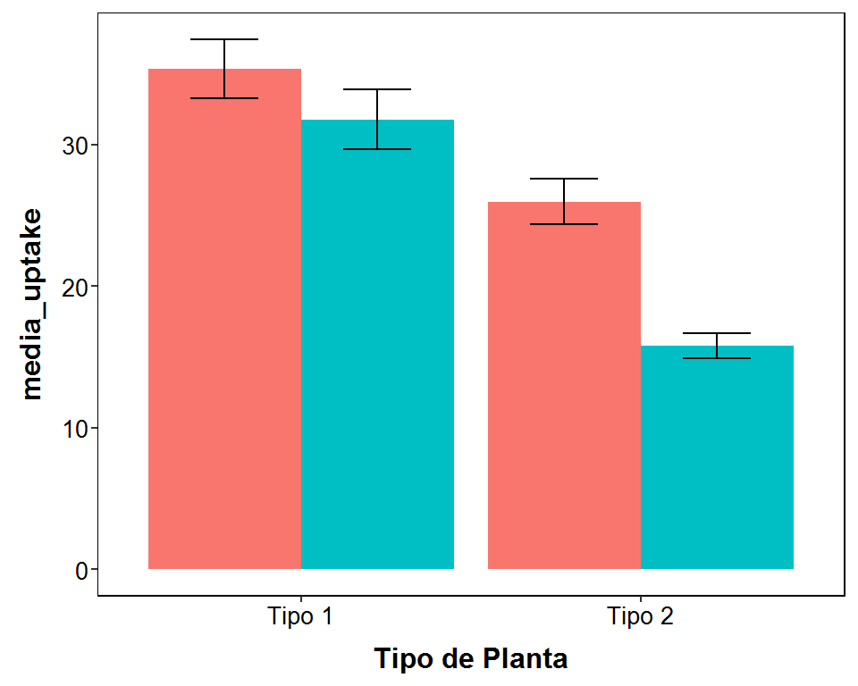

```r
figura <- figura +
  scale_x_discrete("Tipo de Planta",
                   labels = c("Quebec" = "Tipo 1", "Mississippi" = "Tipo 2"))
figura
```

## Alterar a escala no eixo y

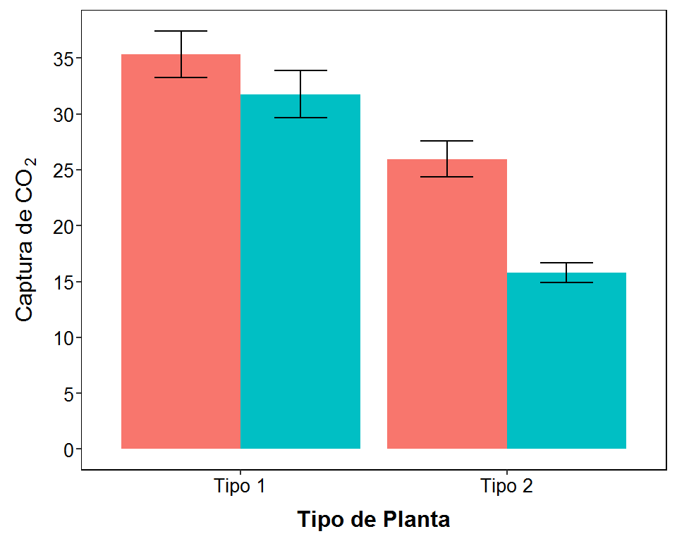

```r
figura +
  scale_y_continuous(expression(paste("Captura de CO "[2])),
                     breaks = seq(0, 45, by = 5))
```

## Alterar a escala no eixo y

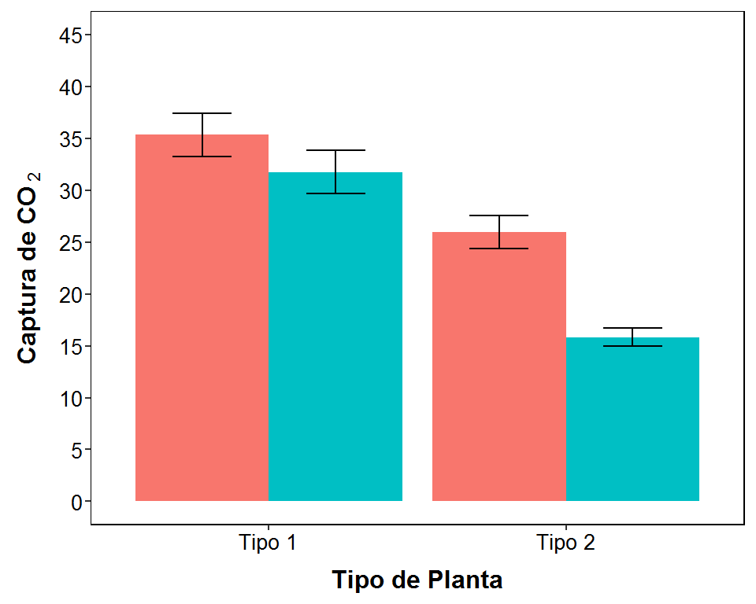

```r
figura +
  scale_y_continuous(expression(bold(paste("Captura de CO "[2]))),
                     breaks = seq(0, 45, by = 5),
                     limits = c(0, 45))
```

## Alterar a escala no eixo y

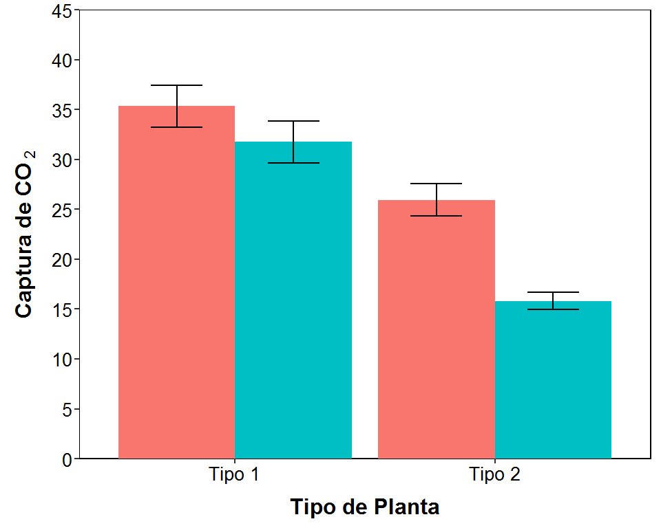

```r
figura <- figura +
  scale_y_continuous(expression(bold(paste("Captura de CO "[2]))),
                     breaks = seq(0, 45, by = 5),
                     limits = c(0, 45), expand = c(0,0))
figura
```

## Alterar as cores das barras

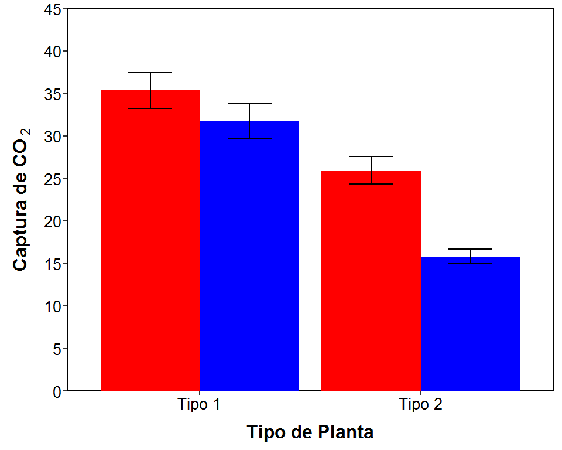

```r
figura <- figura +
  scale_fill_manual(values = c("chilled" = "blue", "nonchilled" = "red"))
figura
```

## Adicionar algum texto ao gráfico

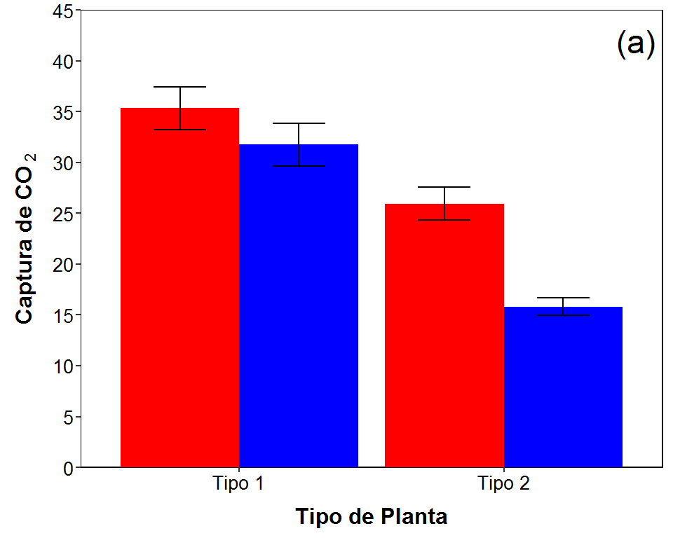

```r
figura <- figura +
  annotate(geom = "text", x = 2.5, y = 42, label = "(a)", size = 6)
figura
```

## Salvando um gráfico do ggplot

- A função `ggsave` pode ser usada para salvar uma figura feita no ggplot2, em qualquer formato que você desejar;
- Você também pode usar as funções disponíveis no pacote `base`, como `pdf`, `tiff` e `jpeg`;
- Para gráficos com mais de um painel, você pode usar a função `grid.arrange` para criar o gráfico de painel, e depois usar as funções do pacote `base` para salvá-las.

```r
ggsave(filename = "/Users/Nick/Dropbox/R PPGE_UFRJ/3 - Quarta/figures/figura.png",
       plot = figura, width = 15, height = 10, units = "cm", dpi = 200)
```

## Mais sobre o ggplot2

- O livro *ggplot2* do Hadley Wickham;
- O site (http://ggplot2.org);
- O Google.